# Reproducible Research: Peer Assessment 1

## Introduction

This assignment makes use of data from a personal activity monitoring device. This device collects data at 5 minute intervals through out the day. The data consists of two months of data from an anonymous individual collected during the months of October and November, 2012 and include the number of steps taken in 5 minute intervals each day.

## Data Source

Dataset Available here:https://d396qusza40orc.cloudfront.net/repdata%2Fdata%2Factivity.zip

**Fileformat:** CSV

17,568 observations presented

**Variables**:

- *steps*: Number of steps taking in a 5-minute interval (missing values are coded as NA)
- *date*: The date on which the measurement was taken in YYYY-MM-DD format
- *interval*: Identifier for the 5-minute interval in which measurement was taken

## Loading and preprocessing the data

```r
##Above all we set language preferences to English (to weekday function can produce correct results) and save current settings
## In order to save my russian environment
curr_locale <- Sys.getlocale("LC_TIME")

## To set it in english
Sys.setlocale("LC_TIME","en_US.UTF-8")
```

```r
##Unzipping file fromm the forked repository
if(!file.exists('activity.csv')){
        unzip('activity.zip')
}
activity_data <- read.csv("activity.csv")

##Formatting dates as Date
activity_data$date <- as.Date(activity_data$date,"%Y-%m-%d")
```

## What is mean total number of steps taken per day?

#### 1. Make a histogram of the total number of steps taken each day

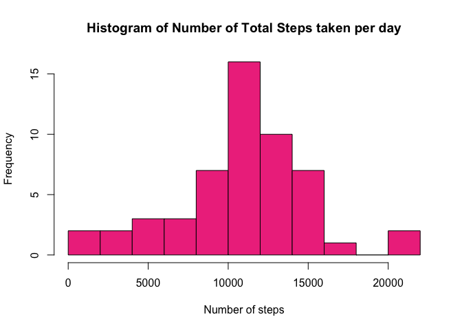

```r
Total_steps_day <- tapply(activity_data$steps, activity_data$date,sum)

##Plotting the histogram (number of breaks was find by plotting several plots)
hist(Total_steps_day, breaks=10, col="violetred2",xlab="Number of steps",
     ylab="Frequency", main="Histogram of Number of Total Steps taken per day")
```

#### 2. Calculate and report the mean and median total number of steps taken per day

```r
Mean_tsd2 <- mean(Total_steps_day, na.rm = TRUE)
Median_tsd2 <- median(Total_steps_day,na.rm = TRUE)
```

Mean is:

```
## [1] 10766.19
```

Median is:

```
## [1] 10765
```

## What is the average daily activity pattern?

#### 1. Make a time series plot (i.e. type = “l”) of the 5-minute interval (x-axis) and the average number of steps taken, averaged across all days (y-axis)

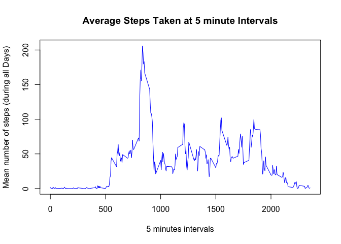

```r
mean_steps <- tapply(activity_data$steps,activity_data$interval,
                    mean,na.rm=TRUE)
plot(names(mean_steps), mean_steps , type="l", xlab="5 minutes intervals",
     ylab="Mean number of steps (during all Days)",
     main="Average Steps Taken at 5 minute Intervals",
     col="blue")
```

### Plotting a little bit more beatiful plot ( with time at x-axis)

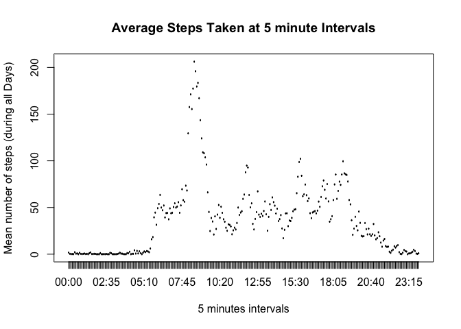

```r
##Function to create x-axis
intName <- function(interval) {
        if (as.numeric(interval) < 10) {
                t_interval = paste("00:0",interval, sep="")
        } else if (as.numeric(interval) >= 10 && as.numeric(interval) < 100) {
                t_interval = paste("00:", interval, sep="")
        } else if (as.numeric(interval) >= 100 && as.numeric(interval) < 1000) {
                t_interval = paste("0", substr(interval,1,1),":", substr(interval,2,3), sep="")
        } else {
                t_interval = paste(substr(interval,1,2),":", substr(interval,3,4), sep="")
        }
}
yax<-names(mean_steps)
for (i in 1:length(names(mean_steps))){
                yax[i]<-intName(names(mean_steps)[i])
}

yax<-as.factor(yax)
plot(yax, mean_steps, xlab="5 minutes intervals",
     ylab="Mean number of steps (during all Days)",
     main="Average Steps Taken at 5 minute Intervals",
     col="blue")
```

#### 2. Which 5-minute interval, on average across all the days in the dataset, contains the maximum number of steps?

```r
#5-minutes interval with maximum steps taken
max_steps_interval <- which.max(mean_steps)
msi <- names(max_steps_interval)
print(msi)
```

```
## [1] "835"
```

Which means that interval “8:35” is the interval with maximum steps taken on average.